# Developing Autonomous Agents in Practice with LangChain

**Speaker:** Gianluca Aguzzi  
**Email:** gianluca.aguzzi@unibo.it  
**GitHub:** cric96

[figure not shown]

## About Me

[figure not shown]

### Gianluca Aguzzi

- 🎓 *Postdoctoral Researcher* at the University of Bologna
- 🔬 Research Interests:
  - Engineering *Large Scale* Distributed Systems
  - Software Engineering 3.0 (*LLMs*, AI-assisted development)
  - Application of AI in software engineering practices

Ok, let's dive into LangChain and discover how to build applications with LLMs! 😊

## Lesson Goals

- **Understand fundamental principles** of building applications with Large Language Models (LLMs)
- **Gain hands-on experience** using LangChain to develop LLM-powered solutions
- **Learn integration techniques** for connecting LLMs with external tools and data sources
- **Master the design and implementation** of autonomous agents that can perform tasks independently

## Autonomous Agents

> **Autonomous agents** are software entities that can perform *tasks* or make decisions **without human intervention**.
- **Autonomous?**
  - Operate *independently*, making decisions based on their *programming* and *learned* experiences (via environment interactions).
- This is a **long-standing research topic in AI**
- Recently, **LLMs** have been used to create agents (perhaps not completely autonomous)
- **How can LLMs be conceived as *agents*?**

## LLM - In a Nutshell

> A **Language Model** is a Machine Learning model which is able to **understand and generate human language**
- **How does it work internally?**
  - Long story, please look at: [3Blue 1 Brown - How does a Language Model work?](https://www.youtube.com/watch?v=wjZofJX0v4M)
  - ... But in a nutshell, it takes a sentence and tries to **predict the next token**
- **Only that?**
  - Yes (more or less), an LM has **no *memory***, **no *environment interaction***, or anything else
- ... But we can **instrument these models to use external tools** (or to be **chained** with each other) to make them **powerful agents**! 😊

## LLMs Panorama: How to Use Them? 🌐🤖

Access LLMs through various providers and models:

- **API Providers**:
  - OpenAI, Anthropic (Claude), Google (Gemini), etc.
- **Open Source Models** (HuggingFace):
  - Llama Family, Qwen, Gemma, Mistral, etc.

Despite the differences, they all share the same concept:

- **Input**: A text prompt (question, instruction, etc.)
- **Output**: A text response (answer, completion, etc.)

## LLM Applications: How to Build Them?

- Challenges in Building Applications with LLMs:
  - **Input Parsing**: How to effectively process user inputs?
  - **Output Formatting**: How to structure responses for clarity and usability?
  - **Error Handling**: How to manage unexpected behaviors or failures?
  - **Conversation Management**: How to maintain context in multi-turn interactions?
  - **External Data Integration**: How to connect with databases, APIs, or other data sources?
  - **Workflow Orchestration**: How to seamlessly integrate multiple steps or components?

**Solution**: This is where **LangChain** excels!

## LangChain - Overview

> **The** platform for reliable agents

[figure not shown]

[🌐 Visit the LangChain Website → langchain.com](https://www.langchain.com/)

## LangChain - Models

**LangChain provides a *unified interface* for interacting with a wide range of Large Language Models (LLMs):**

- **Supports major providers** such as **OpenAI**, **Anthropic**, **Google**, and a variety of open-source models from **HuggingFace**.
- **Enables seamless integration** of different LLMs within a single application.
- **Includes support for embeddings**, which are essential for tasks like semantic search, text similarity, and information retrieval.

[figure not shown]

### LLMs providers

- An LLM is essentially a **function** that takes a string as input and returns a string as output.
- The main method to interact with an LLM is the `invoke` method:
- This provides a **uniform interface** to interact with LLMs, regardless of the provider or model used.

[figure not shown]

### Ollama

Is a local LLM provider that allows you to run models on your own machine. See [Ollama](https://ollama.com/) for more details.

```python
# import langchain gemini and ollama
from langchain_ollama.llms import OllamaLLM
qwen = OllamaLLM(model="qwen2.5:1.5b")
# Example query
qwen.invoke("Explain machine learning in simple terms (max 50 words)")
```

```
"Machine Learning is when computers get better at tasks without being explicitly programmed to do so. It's like training a computer to recognize pictures of cats by showing it many images, and over time, the computer starts recognizing other similar cats too. This way, it learns patterns in data tha…
```

### Gemini

- **Gemini** is a chat-oriented language model developed by Google.
- Designed for multi-turn conversations and advanced dialogue management.
- Suitable for tasks requiring context retention and conversational flow.
- For usage details, refer to [Google AI Studio](https://aistudio.google.com/prompts/new_chat).

```python
# Same for gemini
from dotenv import load_dotenv # used to load environment variables
load_dotenv()  # Load environment variables from .env file
from langchain_google_genai import GoogleGenerativeAI
gemini = GoogleGenerativeAI(model="gemini-2.0-flash", temperature=0.0)
gemini.invoke("Explain machine learning in simple terms (max 50 words)")  # Example query
```

```
'Machine learning teaches computers to learn from data without explicit programming. It identifies patterns and makes predictions or decisions based on that learning, improving its accuracy over time with more data.'
```

### Base Language Model

[figure not shown]

```python
from langchain_core.language_models.base import BaseLanguageModel

def explain_topic(llm: BaseLanguageModel, topic: str) -> str:
    """ A general explain topic functionality base on an LLM"""
    query = f"Explain {topic} in simple terms? (max 50 words)"
    response = llm.invoke(query)
    return response
```

```python
explain_topic(gemini, "London"), explain_topic(qwen, "London")
```

```
("London is the capital of England and the United Kingdom. It's a huge, diverse city with a rich history, famous landmarks like Big Ben and Buckingham Palace, and a vibrant cultural scene. It's a global hub for finance, fashion, and the arts.",
 "London is the capital city of England and one of the world's largest cities with over eight million residents. It sits on the River Thames, surrounded by green parks like Hyde Park. Famous landmarks include Buckingham Palace, Big Ben, Tower Bridge, and many museums. The city offers a mix of histor…
```

### Chat Models

- **Normal LLMs** are seen as simple **stateless** functions.
- **Chat models** are more advanced: they can handle **conversations** with multiple turns.
- **How?**
  - They use a **list of messages** as input, where each message has a role (**user**, **assistant**, **system**, etc.).
- The `invoke` method is used to send a list of messages to the model and get a response.
- **Note:**
  - Even for chat models, the model itself is **stateless**: the conversation history is **not stored by the model**—it's up to the user (or application) to manage and provide the history.

[figure not shown]

### Chat Models vs BaseModel

| Aspect | Base Model | Chat Model |
| --- | --- | --- |
| **Input** | Plain text prompt | List of structured messages |
| **Designed for** | One-shot completions | Multi-turn conversations |
| **Output** | Text completion | Message object |
| **Classes in LangChain** | `BaseLanguageModel` | `BaseChatModel` |

```python
# Chat models
from langchain_google_genai import ChatGoogleGenerativeAI
chat_gemini = ChatGoogleGenerativeAI(model="gemini-2.0-flash", temperature=0.0)
chat_gemini.invoke("Explain machine learning in simple terms").content[:100]  # Example query
```

```
'Imagine you\'re teaching a dog a new trick, like "fetch." You don\'t tell the dog exactly how to run, '
```

### Embeddings

- **Embeddings** are numerical representations of text that capture semantic meaning.
- They are specialized language models designed to represent text as vectors, rather than generate text.
- Embeddings are used for various purposes, such as **augmenting LLM context**, **semantic search**, **clustering**, and similarity analysis.

[figure not shown]

### Embeddings - Semantics

- **What does it mean to *capture semantics*?**
- In the context of **embeddings**, *semantics* refers to the **meaning** and **relationships** between words or phrases.
- As illustrated in the image below, **words with similar meanings are positioned close to each other** in the vector space.
- By applying **distance** or **similarity measures**, we can identify words or texts that are *semantically related*.

[figure not shown]

```python
# Embedings
from langchain_google_genai.embeddings import GoogleGenerativeAIEmbeddings

google_embeddings = GoogleGenerativeAIEmbeddings(model="models/text-embedding-004")
google_embeddings.embed_query("What is the weather like in London?")[:5]
```

```
[-0.024339474737644196,
 0.019421163946390152,
 -0.005040269810706377,
 -0.021117379888892174,
 -0.030608780682086945]
```

### Embeddings - Visual Example of Semantic Similarity

- The dataset contains a list of questions and answers on **three distinct topics**.
- For each question and answer, we compute the corresponding **embeddings**.
- We then use **PCA** to project the embeddings into two dimensions and **visualize** whether clusters emerge.

```python
import pandas as pd
df = pd.read_csv("data/dataset.csv", delimiter=";")  # Example of reading a CSV file with pandas
df.head()
```

|  | Topic | Question | Answer |
| --- | --- | --- | --- |
| 0 | Naruto | Who is the main protagonist of the series? | Naruto Uzumaki |
| 1 | Naruto | What is the name of Naruto's signature ninja t... | Rasengan |
| 2 | Naruto | Which village does Naruto belong to? | Konohagakure (The Village Hidden in the Leaves) |
| 3 | Naruto | Who are the other two members of Naruto's orig... | Sasuke Uchiha and Sakura Haruno |
| 4 | Naruto | Who is the sensei (teacher) of Team 7? | Kakashi Hatake |

```python
# We add embedding to the pandas dataframe
from langchain_core.embeddings import Embeddings
def embed_row(row: pd.Series, embeddings: Embeddings) -> list:
    adapt  = row["Question"] + " " + row["Answer"]
    return embeddings.embed_query(adapt)

df["embeddings"] = df.apply(lambda row: embed_row(row, google_embeddings), axis=1)
df.head()  # Display the first few rows of the DataFrame with embeddings
```

|  | Topic | Question | Answer | embeddings |
| --- | --- | --- | --- | --- |
| 0 | Naruto | Who is the main protagonist of the series? | Naruto Uzumaki | [-0.06318295747041702, -0.025433462113142014, ... |
| 1 | Naruto | What is the name of Naruto's signature ninja t... | Rasengan | [-0.016836581751704216, -0.02863299660384655, ... |
| 2 | Naruto | Which village does Naruto belong to? | Konohagakure (The Village Hidden in the Leaves) | [-0.05141858384013176, 0.014148241840302944, 0... |
| 3 | Naruto | Who are the other two members of Naruto's orig... | Sasuke Uchiha and Sakura Haruno | [-0.0174933560192585, -0.008309093303978443, 0... |
| 4 | Naruto | Who is the sensei (teacher) of Team 7? | Kakashi Hatake | [-0.0031194821931421757, -0.05045430734753609,... |

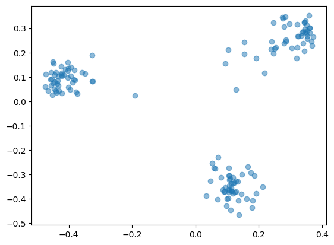

```python
# PCA + rendering
from sklearn.decomposition import PCA
import matplotlib.pyplot as plt

pca = PCA(n_components=2)
pca_result = pca.fit_transform(list(df["embeddings"]))

plt.scatter(pca_result[:, 0], pca_result[:, 1], alpha=0.5)
plt.show()
```

## Prompts

- **Definition:** A **prompt** is a structured input that **guides** the LLM to generate the desired output.
- **Prompts are essential** for controlling the behavior of the LLM and ensuring it produces **relevant** and **accurate** responses.
- **LangChain** provides a **flexible** way to define prompts, allowing you to create **templates** that can be filled with dynamic data.

[figure not shown]

### Prompts - Pratical Example

A prompt is a text with some `holes` (template) that can be filled with dynamic data.

```python
# Prompts
template = """
Translate the following text into {target_language} while maintaining the style of {style}.
Reply just with the translation:

{text}
"""
template
```

[output not shown]

### Prompt Template

> **In LangChain, prompt templates are the *foundation* for dynamic, reusable, and powerful LLM interactions!**

A `PromptTemplate` lets you define a prompt with *placeholders* that can be filled at runtime, enabling you to:

- **Dynamically generate prompts** for different tasks and inputs.
- **Reuse prompt logic** across multiple workflows.
- **Control the structure and clarity** of your LLM requests.

**Key Components:**

- **`template`**: The text with `{placeholders}` for dynamic values.
- **`input_variables`**: The list of variable names to fill in the template.
- **`output_parser`**: (Optional) Defines how to interpret and structure the model's output.

> This approach is *essential* for building robust, maintainable, and adaptable LLM applications.

[figure not shown]

```python
from langchain.prompts import ChatPromptTemplate
prompt_template = ChatPromptTemplate.from_template(template)
prompt_template.input_variables, prompt_template.messages[0].prompt
```

```
(['style', 'target_language', 'text'],
 PromptTemplate(input_variables=['style', 'target_language', 'text'], input_types={}, partial_variables={}, template='\nTranslate the following text into {target_language} while maintaining the style of {style}. Reply just with the translation:\n\n{text}\n'))
```

### Example: Prompt for Translation in a Certain Style/Language

```python
prompt_template.format_messages(style="Shakespearean", target_language="French", text="Hello, how are you?")
```

```
[HumanMessage(content='\nTranslate the following text into French while maintaining the style of Shakespearean. Reply just with the translation:\n\nHello, how are you?\n', additional_kwargs={}, response_metadata={})]
```

```python
def translate_text(llm: BaseLanguageModel, text: str, style: str, target_language: str) -> str:
    prompt = prompt_template.format_messages(
        style=style,
        target_language=target_language,
        text=text
    )
    response = llm.invoke(prompt)
    return response

print(translate_text(gemini, "Hello, how are you?", "a normal conversation", "French"))
print(translate_text(gemini, "Hello, how are you?", "elegant and noble", "Italian"))
```

```
Salut, comment ça va ?
Salute, come state?
```

## Structured Output

- **Definition:** Structured output refers to a specific, predefined format that the LLM is expected to generate in response to a prompt.

[figure not shown]

### Output: Why Structured?

- **Structured output is essential for reliably parsing and integrating LLM results into other applications or workflows.**
- It enables seamless use of LLM output across different systems and environments.

### 🚩 Task: Extracting Cognitive Load from Text

**Output Example:**

```python
## Output parser
{
    "cognitive_load": 10,
    "language": "English",
    "style": "Aristocratic",
    "text": "Hello, how are you?"
}
```

```
{'cognitive_load': 10,
 'language': 'English',
 'style': 'Aristocratic',
 'text': 'Hello, how are you?'}
```

### Zero-Shot Prompting for Structured Output

- **Goal:** Guide the LLM to produce structured outputs by describing the expected format and required information.
- **Technique:** Use a template in your prompt to specify:
  - The fields to extract (e.g., cognitive load, language, style, text)
  - The output format (e.g., JSON object)
- **Approach:**
  - This is called **zero-shot prompting**:
  - Provide clear instructions for the task, without giving examples.

```python
review_template = """
For the following text, extract the following information:

1. Cognitive load (0-100): is the text easy to understand?
2. Language: what language is the text written in?
3. Style: what is the style of the text? (e.g., formal, informal, technical, etc.)
4. Text: the original text.

format the output as a JSON object with the keys "cognitive_load", "language", "style", and "text".

text: {text}
"""
```

- Does this *zero-shot* approach works?
- Kind of :))

```python
simple_text = "Hello, how are you?"
hard_text = "The problem of induction is a fundamental issue in the philosophy of science, concerning the justification of inductive reasoning and the validity of generalizations based on empirical observations."

message_template_chat = ChatPromptTemplate.from_template(review_template)
response = chat_gemini.invoke(message_template_chat.format_messages(text=simple_text))
response.content
# How to parse it?
```

````
'```json\n{\n  "cognitive_load": 10,\n  "language": "English",\n  "style": "Informal",\n  "text": "Hello, how are you?"\n}\n```'
````

Ok, it is a valid json but how i can use it?

### Response Schema & Structured Output Parser

- **Response Schema**: Defines expected output fields (name, description, type) for LLM responses.
- **Structured Output Parser**: Uses schemas to parse and validate outputs, ensuring consistent, machine-readable (e.g., JSON) results.

**Why use them?**

- Reliable, error-free extraction of structured data.
- Simplifies integration and downstream processing.

```python
from langchain.output_parsers import ResponseSchema
from langchain.output_parsers import StructuredOutputParser

cognitive_load_schema = ResponseSchema(name="cognitive_load", description="Cognitive load of the text (0-100)", type="number")
language_schema = ResponseSchema(name="language", description="Language of the text", type="string")
style_schema = ResponseSchema(name="style", description="Style of the text", type="string")
text_schema = ResponseSchema(name="text", description="Original text", type="string")
response_schemas = [cognitive_load_schema, language_schema, style_schema, text_schema]
output_parser = StructuredOutputParser.from_response_schemas(response_schemas)
```

```python
# Review template (with instructions)
review_template_instructions = """
For the following text, extract the following information:

1. Cognitive load (0-100): is the text easy to understand?
2. Language: what language is the text written in?
3. Style: what is the style of the text? (e.g., formal, informal, technical, etc.)
4. Text: the original text.

text: {text}

{format_instructions}
"""
```

```python
from langchain_core.language_models.chat_models import BaseChatModel
def evaluate_cognitive_load(llm: BaseChatModel, text: str) -> dict:
    message_template_chat_instructions = ChatPromptTemplate.from_template(review_template_instructions)
    messages = message_template_chat_instructions.format_messages(text=text,
                                format_instructions=output_parser.get_format_instructions())
    return output_parser.parse(chat_gemini.invoke(messages).content)
```

```python
evaluate_cognitive_load(chat_gemini, simple_text)["cognitive_load"], evaluate_cognitive_load(chat_gemini, hard_text)["cognitive_load"]
```

```
(5, 65)
```

## Memory

- **Definition**: Memory in LangChain allows you to store and retrieve information across multiple interactions
- **Purpose**: It enables the LLM to maintain context and continuity in conversations, making it more effective for multi-turn interactions.
- Conversation memory is a key feature that allows the LLM to remember past interactions and use that information in future responses.

[figure not shown]

### Memory types

- Several types of memory are available, including:
  - **Conversation Memory**: Stores the history of interactions in a conversation.
  - **Buffer Memory**: Temporarily holds information during a session.
  - **Summary Memory**: Summarizes past interactions to maintain context without storing all details

[figure not shown]

### Conversation Chain

- A conversation us a sequence of interactions between the user and the LLM
- **Purpose:** Maintain context and continuity in multi-turn conversations.
- **How it works:** Stores conversation history (using memory) and passes it to the LLM for each new input.

[figure not shown]

```python
from langchain.memory import ConversationBufferMemory
from langchain.chains import ConversationChain
memory = ConversationBufferMemory()
conversation = ConversationChain(
    llm=chat_gemini,
    memory=memory,
    verbose=False
)
memory.buffer
```

```
''
```

```python
conversation.invoke("Hi! My name is Gianluca")["response"][:50]
```

```
"Hi Gianluca! It's nice to meet you. My name is, we"
```

```python
conversation.invoke("What is your role in the society?")["response"][:50]
```

```
"That's a great question, Gianluca! As a large lang"
```

```python
conversation.invoke(input="What is my name?")["response"][:50]
```

```
'You told me your name is Gianluca!'
```

```python
memory.buffer[:500]
```

```
"Human: Hi! My name is Gianluca\nAI: Hi Gianluca! It's nice to meet you. My name is, well, I don't really *have* a name in the traditional sense. You can just call me AI. I'm a large language model, trained by Google. I've been trained on a massive dataset of text and code, which allows me to commun…
```

```python
memory.load_memory_variables({})
```

[output not shown]

### Window Memory

- **Window Memory** is a type of memory that stores a fixed number of recent interactions.
- **Purpose:** Useful for short conversations (and small models) where you want to keep the context without storing all the details.

```python
## Buffer memory
from langchain.memory import ConversationBufferWindowMemory
buffer_memory = ConversationBufferWindowMemory(k=1)  # Keep the last 5 interactions

conversation_short_window = ConversationChain(
    llm=chat_gemini,
    memory=buffer_memory,
    verbose=False
)

conversation_short_window.predict(input="Hi! My name is Gianluca")
conversation_short_window.predict(input="What is your role in the society?")
conversation_short_window.predict(input="What about rasengan")
conversation_short_window.predict(input="What is my name?")
```

```
"As an AI, I don't have access to personal information about you, including your name. We haven't exchanged that information, so I don't know it. You would have to tell me!"
```

### Summary Memory

- **Summary memory** maintains context by summarizing previous interactions, rather than storing every message in detail.
- This approach helps keep conversations concise and relevant, especially for long or complex dialogues.
- Useful when working with models that have input length limitations, as it preserves essential information while reducing memory size.

```python
# Several alternatives, ConversationTokenMemory, ConversationSummaryMemory
from langchain.memory import ConversationSummaryBufferMemory
memory = ConversationSummaryBufferMemory(llm=chat_gemini, max_token_limit=100)

conversation = ConversationChain(
    llm=chat_gemini,
    memory=memory,
    verbose=False
)
long_history = """
Carlo Magno, also known as Charlemagne, was a medieval emperor who ruled much of Western Europe from 768 to 814. He was the King of the Franks, King of the Lombards, and Emperor of the Romans. His reign marked the Carolingian Renaissance, a revival of art, culture, and learning based on classical models. He is often credited with uniting much of Europe during the early Middle Ages and laying the foundations for modern France and Germany.
"""
conversation.invoke(long_history)
conversation.invoke("Was Carlo Magno a king?")
```

```
{'input': 'Was Carlo Magno a king?',
 'history': "System: The human provides a summary of Charlemagne's reign, highlighting his role as a medieval emperor, his unification of Europe, and the Carolingian Renaissance. The AI responds, praising the summary and adding details about Charlemagne's balance of military expansion and cultural r…
 'response': 'Ah, "Carlo Magno"! I see you\'re using the Italian version of his name. Yes, absolutely, Carlo Magno – Charlemagne – was indeed a king! He wasn\'t *just* an emperor, you see. He actually became King of the Franks in 768 AD, jointly ruling with his brother Carloman I until Carloman\'s d…
```

```python
memory.load_memory_variables({})
```

```
{'history': "System: The human provides a summary of Charlemagne's reign, highlighting his role as a medieval emperor, his unification of Europe, and the Carolingian Renaissance. The AI responds, praising the summary and adding details about Charlemagne's balance of military expansion and cultural r…
```

## Chains (Everything is a Chain :))

- **Chain:** A sequence of modular steps (LLM, retriever, memory, etc.) that process input and produce output.
- **Why use them?**
  - Orchestrate complex workflows
  - Reuse and compose logic
  - Maintain context and manage data flow

[figure not shown]

### Example: A simple chain with a prompt and an LLM

[figure not shown]

```python
# Chains
from langchain.chains import LLMChain
prompt = ChatPromptTemplate.from_template(
    "What is the best name to describe \
    a company that makes {product}?"
)
chain = prompt | chat_gemini  # Chain the prompt with the LLM

chain.invoke("bicycles").content[:300]  # Example query
```

```
'The "best" name depends on the specific brand identity you want to create. Here\'s a breakdown of different approaches and examples:\n\n**1. Classic & Traditional:**\n\n*   **Focus:** Heritage, craftsmanship, reliability.\n*   **Examples:**\n    *   [Your Last Name] Cycles (e.g., "Smith Cycles")\n …
```

```python
second_prompt = ChatPromptTemplate.from_template(
    "Write a 20 words description for the following \
    company:{company_name}"
)

chain = chain | second_prompt | chat_gemini  # Chain the prompt with the LLM

chain.invoke("bicycles").content[:300]  # Example query
```

```
'We craft unique bicycle names, from classic to quirky, ensuring brand identity, target audience alignment, and memorability for your cycling company.'
```

### Example: Advanced Chain with Multiple Steps

1. **Translate the review**:  
   The input review is first translated into English using a prompt and the LLM.
2. **Parallel processing**:  
   The translated review is then passed to two chains in parallel:
   - One summarizes the review in a single sentence.
   - The other detects the language of the translated review.
3. **Follow-up generation**:  
   The summary and detected language are used to generate a follow-up response, using another prompt that takes both as input.
4. **Result**:  
   The final output includes the translated review, its summary, the detected language, and a follow-up response—all produced in a single, composable chain.

[figure not shown]

```python
## Advanced chaining
from langchain_core.runnables import RunnablePassthrough
from langchain_core.output_parsers import StrOutputParser
first_prompt = ChatPromptTemplate.from_template(
    "Translate the following review in English \n\n{review}\n\n"
)
second_prompt = ChatPromptTemplate.from_template(
    "Summarize the the following review in a single sentence \n\n{review}\n\n",

)
third_prompt = ChatPromptTemplate.from_template(
    "What is the language of the following review? \n\n{review}\n\n"
)
fourth_prompt = ChatPromptTemplate.from_template(
    "Write a follow up response to the following summary in the specified language \n\nSummary:{summary}\n\n Language:{language}\n\n"
)
```

```python
# Simple Chaining
# 1. Translate the review
translate_chain = first_prompt | chat_gemini
# 2. Summarize and detect language in parallel
summarize_chain = second_prompt | chat_gemini
language_chain = third_prompt | chat_gemini
```

### RunnablePassthrough: Why?

- **RunnablePassthrough** is a special type of runnable that allows you to pass data through a chain without modifying it.
- **Purpose**: Adapt the flow of data in a chain without altering its content.
- **Why is it needed in LangChain?**
  - When building complex chains, you often need to "fork" or "branch" the data, assign new fields, or pass the original input alongside intermediate results.
  - `RunnablePassthrough` enables you to enrich or transform the data at different steps, while keeping the original input available for later use.
  - It is essential for advanced workflows where multiple steps depend on the same input or on outputs from previous steps.

**Example use case:**  
When you want to run several chains in parallel on the same input, or assign new keys to the data dictionary as it flows through the chain, `RunnablePassthrough` helps you manage and structure this data flow efficiently.

```python
# 3. Combine
full_chain = (
    RunnablePassthrough.assign(
        translated=translate_chain
    )
    .assign(
        summary=lambda x: summarize_chain.invoke({"review": x["translated"]}),
        language=lambda x: language_chain.invoke({"review": x["translated"]}),
    )
    .assign(
        follow_up=lambda x: (fourth_prompt | chat_gemini).invoke(
            {"summary": x["summary"], "language": x["language"]}
        )
    )
)

# Example input
result = full_chain.invoke({"review": "Das war ein großartiger Aufenthalt! Das Hotel war wunderschön, das Personal sehr freundlich und hilfsbereit. Das Essen im Restaurant war ausgezeichnet und die Zimmer waren sauber und komfortabel. Die Lage war perfekt für Sightseeing. Wir werden definitiv wiederkommen!"})
result["language"].content, result["summary"].content[:50], result["follow_up"].content[:50]
```

```
('The language of the review is **English**.',
 'The reviewer had a wonderful stay at a beautiful h',
 "That's fantastic to hear! We're so glad you enjoye")
```

### Example: Branching Chains

- **Goal:** Route input to different destinations based on a prompt.
- **How it works:**
  - A prompt is used to select the destination based on the input.
  - The selected destination is then used to generate a response.
- The selection is performed via a lambda function that maps the input to the appropriate destination.

[figure not shown]

```python
fishing_template = load_prompt("data/prompts/fishing.txt")
guitar_template = load_prompt("data/prompts/guitar.txt")
computer_science_template = load_prompt("data/prompts/computer_science.txt")
anime_template = load_prompt("data/prompts/anime.txt")
```

```python
prompt_selector = """
Giving the following question, select the most appropriate between the following destinations:
{destinations}
Reply with just the template name, without any additional text. If you don't know the answer, reply with "general"

The question is:
{input}
"""
```

```python
prompt_infos = {
    "fishing": {
        "description": "Good for answering questions about fishing",
        "prompt_template": fishing_template
    },
    "guitar": {
        "description": "Good for answering questions about guitar and music",
        "prompt_template": guitar_template
    },
    "computer science": {
        "description": "Good for answering computer science questions",
        "prompt_template": computer_science_template
    },
    "anime": {
        "description": "Good for answering questions about anime and manga",
        "prompt_template": anime_template
    }
}
destinations = [f"{name}: {info['description']}" for name, info in prompt_infos.items()]
destinations_str = "\n".join(destinations)
destinations_str
```

```
'fishing: Good for answering questions about fishing\nguitar: Good for answering questions about guitar and music\ncomputer science: Good for answering computer science questions\nanime: Good for answering questions about anime and manga'
```

```python
prompt_selector_template = ChatPromptTemplate.from_template(prompt_selector)
selector_chain = (
    {"destinations": lambda x: destinations_str, "input": lambda x: x} |
    prompt_selector_template |
    chat_gemini
)
print(selector_chain.invoke("What is the best way to catch a fish?").content)
print(selector_chain.invoke("What if moon is made of cheese?").content)
```

```
fishing
general
```

```python
semantic_chains = {name: ChatPromptTemplate.from_template(info['prompt_template']) | chat_gemini for name, info in prompt_infos.items()}
```

### RunnableLambda

- RunnableLambda: A special type of runnable that allows you to define custom logic using Python functions.
- **Purpose**: Execute custom code within a chain, enabling dynamic behavior and complex processing.
- **Why is it needed in LangChain?**
  - It allows you to integrate custom logic, calculations, or data transformations directly into the chain
  - This is essential for building flexible and adaptable workflows that can handle a wide range of tasks

```python
from langchain_core.runnables import RunnableLambda

def route_to_chain(data):
    input_text = data["input"]
    category = data["category"].content.strip().lower()

    if category in semantic_chains:
        return semantic_chains[category].invoke(input_text)
    else:
        return chat_gemini.invoke(input_text)

smart_assistant_chain = (
    RunnablePassthrough.assign(
        category=lambda x: selector_chain.invoke(x["input"])
    ) |
    RunnableLambda(route_to_chain)
)
```

```python
# Test the smart assistant
test_questions = [
    "What is the best bait for catching bass?",
    "How do I tune my guitar?",
    "What is machine learning?",
    "Who is the main character in Naruto?",
    "What is the meaning of life?"
]

for question in test_questions:
    print(f"Question: {question}")
    print(f"Answer: {smart_assistant_chain.invoke({'input': question}).content[:50]}")
    print("-" * 50)
```

```
Question: What is the best bait for catching bass?
Answer: Alright, let's talk bass bait! That's a question t
--------------------------------------------------
Question: How do I tune my guitar?
Answer: Alright, let's get your guitar in tune! Tuning is
--------------------------------------------------
Question: What is machine learning?
Answer: Okay, let's break down machine learning. As a comp
--------------------------------------------------
Question: Who is the main character in Naruto?
Answer: Ah, a fantastic question! The main character in Na
--------------------------------------------------
Question: What is the meaning of life?
Answer: Ah, the million-dollar question! The meaning of li
--------------------------------------------------
```

## Agents

- This module provides a framework for building autonomous agents that can interact with the environment, make decisions, and perform tasks.
- **Agents** are designed to be more autonomous than simple chains, allowing them to make **decisions** and take **actions**

[figure not shown]

### Actions -- Tools

- **Actions** are the building blocks of agents, representing specific tasks or operations that the agent can perform.
- **Tools** are a type of action that allows the agent to interact with external systems or services.
- **What is a tool?**
  - A tool is a function that the agent can call to perform a specific action, such as querying a database, making an API call, or executing a command.
  - It has a *name*, a *description*, and an *input schema* that defines the expected input format.
- **Example of a tool**: A function that retrieves weather information based on a location input.

```python
from langchain.agents import tool
import python_weather
from python_weather import Locale

@tool
async def get_weather(location: str) -> str:
    """
    Get the current weather for a given location.

    Args:
        location (str): The name of the location to get the weather for.

    Returns:
        str: A string describing the current weather in the specified location.
    """
    async with python_weather.Client(unit=python_weather.METRIC, locale=Locale.ITALIAN) as client:

        # Fetch a weather forecast from a city.
        weather = await client.get(location)
        return weather.temperature

await get_weather.ainvoke("London")  # Example usage of the tool
```

```
26
```

```python
get_weather
```

```
StructuredTool(name='get_weather', description='Get the current weather for a given location.\n\nArgs:\n    location (str): The name of the location to get the weather for.\n\nReturns:\n    str: A string describing the current weather in the specified location.', args_schema=<class 'langchain_core.u…
```

### How to Perform Search?

- Typically, agents would like to use web search to find information.
- Unfortunatley, those search engines are not designed to be used by agents.
- **Solution**: Use a search engine that provides an API, such as Bing Search or Google Search (via Search API).
- These APIs typically return structured data that can be easily processed by the agent.
- And they shoulbd be paied

### How Agents Selects Tools?

- Agents use a **decision-making process** to select the appropriate tool based on the current context and task requirements.
- This process involves:
  - Analyzing the input and context.
  - Evaluating available tools and their capabilities.
  - Selecting the most suitable tool for the task at hand.
- This is possible via **zero-shot prompting** or **few-shot prompting**
- One of the most common approach is **ReAct**.

### ReAct

- **ReAct** is a framework that combines reasoning and acting in a single process. (Reasoning + Acting)

[figure not shown]

### ReAct: How Does It Work?

- **ReAct** combines prompt engineering with tool usage to enable reasoning and action-taking.
- The core idea: the agent operates in a loop of **Thought → Action → Observation**, guided by a structured prompt.
- The prompt typically includes:
  - Instructions for reasoning (**Thought**)
  - How to select and execute an **Action** (using tools)
  - How to process the **Observation** (action result)
  - How to produce a final **Answer**
- This approach allows agents to solve complex tasks by iteratively thinking, acting, and observing results.

```python
prompt = f"""
You operate in a loop of: Thought, Action, PAUSE, Observation.
At the end of the loop, you output an Answer.

- Use **Thought** to describe your reasoning about the question.
- Use **Action** to execute one of the available actions, then return PAUSE.
- **Observation** will be the result of the action.

Available Actions:
calculate:
    e.g., calculate 2 + 2
    Returns a calculation result.

...

Example Session:
Question: [Your question here]
Thought: [Your reasoning]
Action: [Action to take]
PAUSE
Observation: [Result of the action]
...
Answer: [Final answer]
"""
```

### ReAct In Practice: LangChain

Some tools are already implemented in LangChain, such as:

- **math**: Perform mathematical calculations.
- **serapi**: Perform web searches.
- and many others.

See the [LangChain documentation](https://python.langchain.com/docs/how_to/#tools) for a complete list of available tools.

```python
from langchain.agents import load_tools, initialize_agent
from langchain.agents import AgentType
tools = load_tools(["llm-math", "serpapi"], llm=chat_gemini)
```

### How to initialize an Agent?

In LangChain, an agent is initialized using the `initialize_agent` function, which takes the following parameters:

- Which tools the agent can use
- The LLM to use for reasoning and decision-making
- The type of agent to create (e.g., ReAct, ZeroShotAgent, etc)
- The agent's name and description (optional)

```python
agent = initialize_agent(
    tools,
    chat_gemini,
    agent=AgentType.CHAT_ZERO_SHOT_REACT_DESCRIPTION,
    handle_parsing_errors=True,
    verbose = True
)
```

Given the tasks, the agents will understand the context and select the appropriate tools to perform the actions needed to complete the tasks:

```python
agent.invoke("What is the 25% of ln(17325.124)?")
```

````
> Entering new AgentExecutor chain...
Thought: I need to calculate the natural logarithm of 17325.124 and then multiply the result by 0.25.
Action:
```json
{
  "action": "Calculator",
  "action_input": "ln(17325.124)"
}
```
Observation: Answer: 9.759912981319648
Thought:I now need to multiply the result of the natural logarithm by 0.25.
Action:
```json
{
  "action": "Calculator",
  "action_input": "9.759912981319648 * 0.25"
}
```
Observation: Answer: 2.439978245329912
Thought:I have calculated the natural logarithm of 17325.124 and multiplied the result by 0.25. I now have the final answer.
Final Answer: 2.439978245329912

> Finished chain.
````

```
{'input': 'What is the 25% of ln(17325.124)?', 'output': '2.439978245329912'}
```

```python
chat_gemini.invoke("What is the 25% of ln(17325.124)? reply with just the result").content
```

```
'2.297'
```

In this other case, the agent will use the `serapi` tool to perform a web search

```python
question = "Tom M. Mitchell is an American computer scientist \
and the Founders University Professor at Carnegie Mellon University (CMU)\
what book did he write?"
result = agent(question)
```

````
> Entering new AgentExecutor chain...
Thought: I need to find out what book Tom M. Mitchell wrote. I can use the search tool to find this information.
Action:
```json
{
  "action": "Search",
  "action_input": "Tom M. Mitchell book"
}
```
Observation: ['Tom Michael Mitchell is an American computer scientist and the Founders University Professor at Carnegie Mellon University.', 'Tom M. Mitchell type: American computer scientist.', 'Tom M. Mitchell entity_type: people, scholars.', 'Tom M. Mitchell kgmid: /m/0h7pbt5.', 'Tom M. Mitchell …
Thought:Thought: The search results indicate that Tom M. Mitchell wrote the book "Machine Learning".
Final Answer: Machine Learning

> Finished chain.
````

### Agents - Combine with memory

- Agents can be combined with memory to maintain context across multiple interactions.
- This allows the agent to remember past actions and observations, making it more effective in complex tasks

```python
memory = ConversationBufferMemory(memory_key="chat_history")
agent = initialize_agent(
    [get_weather],
    chat_gemini,
    agent=AgentType.CONVERSATIONAL_REACT_DESCRIPTION,
    handle_parsing_errors=True,
    verbose = False,
    memory=memory,
)
```

```python
await agent.ainvoke("Hello! My name is Gianluca.. What is the weather like in London?")
```

````
{'input': 'Hello! My name is Gianluca.. What is the weather like in London?',
 'chat_history': '',
 'output': 'Hello Gianluca! The current weather in London is 26 degrees.\n```'}
````

```python
await agent.ainvoke("What is my name?")
```

````
{'input': 'What is my name?',
 'chat_history': 'Human: Hello! My name is Gianluca.. What is the weather like in London?\nAI: Hello Gianluca! The current weather in London is 26 degrees.\n```',
 'output': 'Your name is Gianluca.\n```'}
````

### Agents - Can Agents Run Arbitrary Python Code?

- Since ReAct agents can use arbitrary tools, they are also capable of executing Python code.
- This enables agents to perform complex calculations, data processing, or any other programmable task.
- **⚠️ Caution:**
  - Running arbitrary code is powerful but introduces significant security risks if not properly managed!
  - Avoid allowing agents to execute unrestricted code whenever possible.
  - If code execution is necessary, use a sandboxed environment or dedicated, well-audited tools for specific tasks (e.g., math, data processing).
  - Prefer using specialized tools over generic code execution to minimize risk and improve reliability.

````python
from langchain.agents import tool

@tool
def execute_python_code(code: str) -> str:
    """
    Execute the given Python code and return the result.
    """
    try:
        local_vars = {}
        # remove ```python and ``` from the code
        code = code.strip().replace("```python", "").replace("```", "")
        exec(code, {}, local_vars)
        if 'result' in local_vars:
            return str(local_vars['result'])
        return "Code executed successfully."
    except Exception as e:
        return str(e)
````

```python
memory = ConversationBufferMemory(memory_key="chat_history")
agent = initialize_agent(
    [execute_python_code],
    chat_gemini,
    agent=AgentType.CONVERSATIONAL_REACT_DESCRIPTION,
    handle_parsing_errors=True,
    verbose = False,
    memory=memory,
)
```

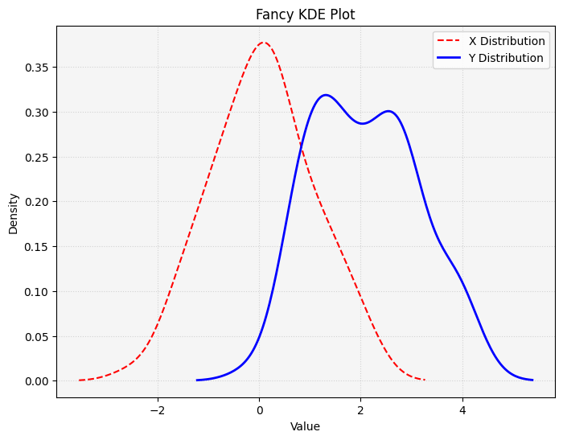

```
{'input': 'Plot a fancy kde with different colors and style with matplotlib',
 'chat_history': '',
 'output': 'I have generated a fancy KDE plot with different colors and styles using matplotlib and scipy.stats. The plot displays the KDE for two different distributions, labeled as "X Distribution" (red, dashed line) and "Y Distribution" (blue, solid line). It includes labels, a title, a legend, a…
```

```python
agent.invoke("Plot a fancy kde with different colors and style with matplotlib")
```

```python
memory = ConversationBufferMemory(memory_key="chat_history")
agent = initialize_agent(
    [execute_python_code],
    chat_gemini,
    agent=AgentType.CONVERSATIONAL_REACT_DESCRIPTION,
    handle_parsing_errors=True,
    verbose = False,
    memory=memory,
)
```

```python
agent.invoke("I have this data: [1, 2, 3, 7, 11]")
```

```
{'input': 'I have this data: [1, 2, 3, 7, 11]',
 'chat_history': '',
 'output': "Okay, I see you have the data [1, 2, 3, 7, 11]. What would you like to do with it? I can help you calculate things like the mean, median, standard deviation, or perform other operations. Just let me know what you're interested in."}
```

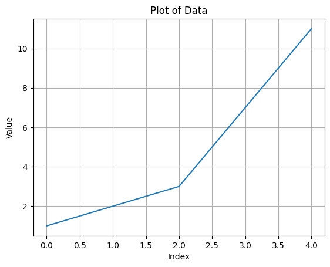

```
{'input': 'Plot them please',
 'chat_history': "Human: I have this data: [1, 2, 3, 7, 11]\nAI: Okay, I see you have the data [1, 2, 3, 7, 11]. What would you like to do with it? I can help you calculate things like the mean, median, standard deviation, or perform other operations. Just let me know what you're interested in.",
 'output': 'I have plotted the data for you. You should be able to see a graph with the data points [1, 2, 3, 7, 11] plotted against their index. The x-axis is labeled "Index", the y-axis is labeled "Value", and the plot has a title "Plot of Data". A grid is also displayed on the plot.'}
```

```python
agent.invoke("Plot them please")
```

### Agents - Modelling Example

```python
from langchain_community.utilities import SerpAPIWrapper

@tool
def search_company_news(company_name: str) -> str:
    """
    Use this tool to find recent news articles and headlines about a specific company.
    The input should be the company's full name (e.g., 'NVIDIA', 'Microsoft').
    This provides qualitative context.
    """
    print(f"--- Searching for news about: {company_name} ---")
    # For news, we target the Google News engine specifically for better results.
    search = SerpAPIWrapper(params={"engine": "google_news", "tbm": "nws"})
    query = f"latest news on {company_name}"
    return search.run(query)
```

```python
@tool
def search_stock_data(company_ticker: str) -> str:
    """
    Use this tool to get the current stock price, market cap, and other key financial metrics
    for a company. The input should be the company's stock ticker symbol (e.g., 'NVDA', 'GOOGL', 'MSFT').
    """
    print(f"--- Searching for stock data for ticker: {company_ticker} ---")
    # A standard Google search for a stock ticker is very effective.
    # SerpAPI will return the contents of the Google Finance widget.
    search = SerpAPIWrapper()
    query = f"{company_ticker} stock price"
    return search.run(query)
```

```python
from dotenv import load_dotenv
load_dotenv()  # Load environment variables from .env file

agent = initialize_agent(
    [search_stock_data, search_company_news],
    chat_gemini,
    agent=AgentType.CHAT_ZERO_SHOT_REACT_DESCRIPTION,
    handle_parsing_errors=True,
    verbose=False
)

agent.invoke("Give me a financial snapshot of Microsoft (MSFT). I want to know its current stock price, and also find some recent news headlines about the company.")
```

```
--- Searching for stock data for ticker: MSFT ---
--- Searching for news about: Microsoft ---
```

```
{'input': 'Give me a financial snapshot of Microsoft (MSFT). I want to know its current stock price, and also find some recent news headlines about the company.',
 'output': "The current stock price for Microsoft (MSFT) is $497.41. Here are some recent news headlines about the company:\n\n*   All-new Surface Copilot+ PCs arrive in Singapore: The Surface Pro, 12-inch and Surface Laptop, 13-inch\n*   Microsoft says new AI tool can diagnose patients 4 times more…
```

### Vector Stores -- Extra

- A **vector store** is a specialized database designed to efficiently store and retrieve high-dimensional vectors, such as embeddings generated by language models.
- **Why use a vector store?**
  - Enables **fast similarity search** and retrieval based on *semantic meaning* (not just keywords).
  - Supports applications like **semantic search**, **question answering**, and **recommendation systems**.
- **How does it work?**
  - Stores vectors (embeddings) representing documents, images, or other data.
  - When you query, it finds items with vectors *closest* to your query vector (using distance metrics like cosine similarity).
- **Think of it as "semantic memory":**
  - Retrieve information that is *similar in meaning*, even if the exact words are different.
- **Popular vector stores:** FAISS, Pinecone, Chroma, Weaviate, Milvus, Qdrant, etc.

[figure not shown]

```python
# Stores
from langchain.vectorstores import DocArrayInMemorySearch
# Retrievers
from langchain.indexes import VectorstoreIndexCreator
# Loaders
from langchain.document_loaders import CSVLoader
```

```python
loader = CSVLoader(file_path='data/dataset.csv')
index = VectorstoreIndexCreator(embedding=google_embeddings, vectorstore_cls=DocArrayInMemorySearch).from_loaders(loaders=[loader])
```

```python
index.vectorstore.search("Is rasengan a powerful attack?", search_type="similarity", k=1)
```

```
[Document(metadata={'source': 'data/dataset.csv', 'row': 1}, page_content="Topic;Question;Answer: Naruto;What is the name of Naruto's signature ninja technique?;Rasengan")]
```

```python
smollm = OllamaLLM(model="smollm:360m")
index.query("What is the best attack of Naruto? Reply with just the attack (a word)", llm=smollm, verbose=True)
```

```
> Entering new RetrievalQA chain...

> Finished chain.
```

```
'The best attack of Naruto is the "Rasengan" technique, which is a powerful and deadly ninja technique that involves using the power of the eyes to strike multiple enemies at once.'
```

```python
smollm.invoke("What is the best attack of Naruto? Reply with just the attack (a word)")
```

```
"The best attack of Naruto!\n\nNaruto's most iconic and effective attacks are the ones that allow him to take down enemies, defeat bosses, or complete challenges. Here are some of the best attacks of Naruto:\n\n1. **Katana Attack**: The Katana is Naruto's signature weapon, and it's a powerful and de…
```

### Indexes: How Do We Evaluate Performance?

- **Why evaluate?**  
  To measure how well your agent or retrieval system answers questions or solves tasks.
- **Evaluation workflow:**
  1. **Generate test cases:**  
     Use an LLM to automatically create realistic questions and answers from your documents or data.
  2. **Run the agent:**  
     Have your agent answer these questions.
  3. **Score the results:**  
     Compare the agent's answers to the ground truth using automated grading (LLM-based or rule-based).
- **Benefits:**
  - Identify strengths and weaknesses of your system.
  - Track improvements as you iterate.
  - Ensure reliability before deploying to users.
- **Tip:**  
  Automate test case generation and evaluation for scalable, repeatable benchmarking!

```python
# Evaluation? How to?
file = 'data/long_dataset.csv'
loader = CSVLoader(file_path=file)
data = loader.load()
```

```python
index = VectorstoreIndexCreator(
    vectorstore_cls=DocArrayInMemorySearch,
    embedding=google_embeddings
).from_loaders([loader])
```

```python
data[0]
```

```
Document(metadata={'source': 'data/long_dataset.csv', 'row': 0}, page_content="Description: Itachi's actions were driven by a profound personal sacrifice to prevent a civil war. The Uchiha clan, feeling marginalized by the Konoha leadership, was planning a coup d'état. Faced with an ultimatum from D…
```

```python
from langchain.chains import RetrievalQA
qa = RetrievalQA.from_chain_type(
    llm=chat_gemini,
    chain_type="stuff", # "stuff" is a simple chain that concatenates documents and passes them to the LLM
    retriever=index.vectorstore.as_retriever(),
    verbose=False,
)
```

To generate test cases, LangChain exposes the `QAGenerateChain` utility.

```python
# How to evaluate? Dataset generation
from langchain.evaluation.qa import QAGenerateChain
example_gen_chain = QAGenerateChain.from_llm(llm=chat_gemini)
```

```python
new_examples = example_gen_chain.apply_and_parse(
    [{"doc": t} for t in data[:5]]
)
```

```python
new_examples
```

```
[{'qa_pairs': {'query': 'According to the document, what ultimatum was Itachi faced with that led to his decision to annihilate the Uchiha clan?',
   'answer': 'Itachi was faced with an ultimatum from Danzo Shimura, which led him to choose to single-handedly annihilate his clan.'}},
 {'qa_pairs': {'query': 'According to the document, what fundamental difference in chakra control do the Rasengan and Chidori represent?',
   'answer': 'The Rasengan represents the pinnacle of shape manipulation, while the Chidori represents the pinnacle of nature transformation.'}},
 {'qa_pairs': {'query': 'According to the document, what is the core philosophy of Konoha known as, and what does it state?',
   'answer': "The core philosophy of Konoha is known as the 'Will of Fire', which states that the entire village is a family and a shinobi's strength comes from their love and loyalty to their comrades and home."}},
 {'qa_pairs': {'query': "According to the document, what was the primary personal tragedy that warped Nagato's ideology and led him to believe that true peace could only be achieved through immense pain and suffering?",
   'answer': 'The death of his friend Yahiko.'}},
 {'qa_pairs': {'query': "According to the document, what specific event, orchestrated by Madara Uchiha, served as the catalyst for Obito Uchiha's descent into villainy?",
   'answer': "The orchestrated death of Rin Nohara at the hands of Kakashi, which Obito witnessed after being saved by Madara Uchiha, served as the catalyst for Obito Uchiha's descent into villainy."}}]
```

```python
import langchain
qa.run(new_examples[0]['qa_pairs']["query"])
```

```
'According to the document, Itachi was faced with an ultimatum from Danzo Shimura. He had to choose between annihilating his clan or face a much larger conflict that would have weakened the village and potentially led to another Great Ninja War.'
```

```python
langchain.debug = False
from langchain.evaluation.qa import QAEvalChain
eval_chain = QAEvalChain.from_llm(chat_gemini)
queries = [ example['qa_pairs'] for example in new_examples ]
predictions = qa.apply(queries)
```

```python
graded_outputs = eval_chain.evaluate(queries, predictions)
```

```python
graded_outputs[0]
```

```
{'results': 'CORRECT'}
```

```python
for i, eg in enumerate(queries):
    print(f"Example {i}:")
    print("Question: " + predictions[i]['query'])
    print("Real Answer: " + predictions[i]['answer'])
    print("Predicted Answer: " + predictions[i]['result'])
    print("Predicted Grade: " + graded_outputs[i]['results'])
    print()
```

```
Example 0:
Question: According to the document, what ultimatum was Itachi faced with that led to his decision to annihilate the Uchiha clan?
Real Answer: Itachi was faced with an ultimatum from Danzo Shimura, which led him to choose to single-handedly annihilate his clan.
Predicted Answer: According to the document, Itachi was faced with an ultimatum from Danzo Shimura.
Predicted Grade: CORRECT

Example 1:
Question: According to the document, what fundamental difference in chakra control do the Rasengan and Chidori represent?
Real Answer: The Rasengan represents the pinnacle of shape manipulation, while the Chidori represents the pinnacle of nature transformation.
Predicted Answer: According to the document, the Rasengan is the pinnacle of shape manipulation, while the Chidori is the pinnacle of nature transformation.
Predicted Grade: CORRECT

Example 2:
Question: According to the document, what is the core philosophy of Konoha known as, and what does it state?
Real Answer: The core philosophy of Konoha is known as the 'Will of Fire', which states that the entire village is a family and a shinobi's strength comes from their love and loyalty to their comrades and home.
Predicted Answer: The core philosophy of Konoha is known as the 'Will of Fire'. It states that the entire village is a family and a shinobi's strength comes from their love and loyalty to their comrades and home. This love fosters a desire for peace and cooperation.
Predicted Grade: CORRECT

Example 3:
Question: According to the document, what was the primary personal tragedy that warped Nagato's ideology and led him to believe that true peace could only be achieved through immense pain and suffering?
Real Answer: The death of his friend Yahiko.
Predicted Answer: According to the document, the primary personal tragedy that warped Nagato's ideology was the death of his friend Yahiko.
Predicted Grade: CORRECT

Example 4:
Question: According to the document, what specific event, orchestrated by Madara Uchiha, served as the catalyst for Obito Uchiha's descent into villainy?
Real Answer: The orchestrated death of Rin Nohara at the hands of Kakashi, which Obito witnessed after being saved by Madara Uchiha, served as the catalyst for Obito Uchiha's descent into villainy.
Predicted Answer: The orchestrated death of Rin Nohara, at the hands of Kakashi, was the catalyst for Obito Uchiha's descent into villainy. Madara Uchiha manipulated this event to break Obito's spirit.
Predicted Grade: CORRECT
```

### Conclusion

- **This was a brief overview of how to build autonomous agents with LangChain.**
- We explored how to:
  - **Use LLMs and embeddings** for language understanding and retrieval
  - **Create prompts** and generate structured outputs
  - **Build and compose chains and agents** for complex workflows
  - **Use memory** to maintain conversational context
- **LangChain is a powerful and flexible framework for building LLM-powered applications.**
- The field is rapidly evolving, with alternative solutions like **LlamaIndex**, **LangGraph**, and more emerging.
- **Thank you for following along—I hope you found this talk insightful and useful!**